# CDTT-CCNA data analysis

**Note: PTA categories**

1. “Normal”: Better ear 4f-PTA ≤ 20 dB HL
2. “Mild”: Better ear 4f-PTA > 20 dB HL and < 40 dB HL
3. “Moderate”: Better ear 4f-PTA ≥ 40 dB HL

**Note: Data exclusion**

1. Original dataset had n=264.
2. Dropped single outlier (PTA < 19 & SRT > 2).
3. Dropped two participants with missing SRT data.
4. All plots and analyses use n=261 now.

### Does cognition change the relationship between PTA and SRT?

*Note: PTA (x-axis) is always jittered slightly to decrease overlap of points.*

#### Figure 1: Three PTA groups with normal, mild, and moderate hearing loss

Conclusion: MoCA changes the relationship between PTA-SRT only for the mild hearing loss group.

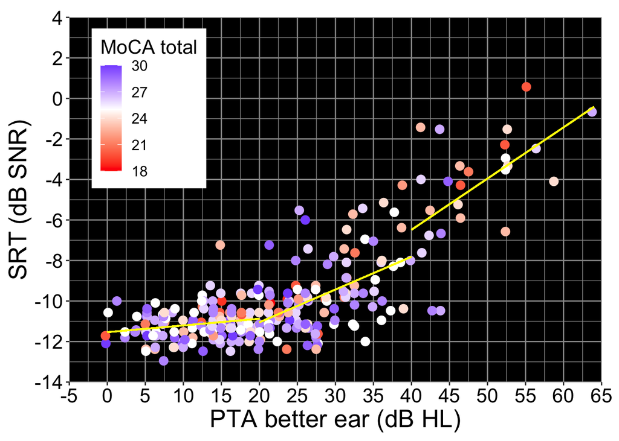

*Across all participants*

```r
summary(lm(SRT ~ PTA.better * MoCA.total, data2))
```

```
##
## Call:
## lm(formula = SRT ~ PTA.better * MoCA.total, data = data2)
##
## Residuals:
##     Min      1Q  Median      3Q     Max
## -3.7883 -0.9570 -0.1238  0.8189  5.9523
##
## Coefficients:
##                         Estimate Std. Error t value Pr(>|t|)
## (Intercept)           -17.968617   1.895360  -9.480  < 2e-16 ***
## PTA.better              0.463565   0.075408   6.147 2.99e-09 ***
## MoCA.total              0.193108   0.073977   2.610  0.00957 **
## PTA.better:MoCA.total  -0.012701   0.002993  -4.244 3.07e-05 ***
## ---
## Signif. codes:  0 '***' 0.001 '**' 0.01 '*' 0.05 '.' 0.1 ' ' 1
##
## Residual standard error: 1.549 on 257 degrees of freedom
## Multiple R-squared:  0.6127, Adjusted R-squared:  0.6081
## F-statistic: 135.5 on 3 and 257 DF,  p-value: < 2.2e-16
```

*Normal hearing only*

```r
summary(lm(SRT ~ PTA.better * MoCA.total, subset(data2, PTA.group == "Normal")))
```

```
##
## Call:
## lm(formula = SRT ~ PTA.better * MoCA.total, data = subset(data2,
##     PTA.group == "Normal"))
##
## Residuals:
##     Min      1Q  Median      3Q     Max
## -1.6149 -0.4875 -0.1365  0.5746  3.6358
##
## Coefficients:
##                         Estimate Std. Error t value Pr(>|t|)
## (Intercept)           -12.340319   1.771647  -6.965 1.54e-10 ***
## PTA.better              0.199657   0.136004   1.468    0.145
## MoCA.total              0.031149   0.067729   0.460    0.646
## PTA.better:MoCA.total  -0.006507   0.005227  -1.245    0.215
## ---
## Signif. codes:  0 '***' 0.001 '**' 0.01 '*' 0.05 '.' 0.1 ' ' 1
##
## Residual standard error: 0.8172 on 128 degrees of freedom
## Multiple R-squared:  0.07504,    Adjusted R-squared:  0.05336
## F-statistic: 3.461 on 3 and 128 DF,  p-value: 0.01838
```

*Mild hearing loss only*

```r
summary(lm(SRT ~ PTA.better * MoCA.total, subset(data2, PTA.group == "Mild")))
```

```
##
## Call:
## lm(formula = SRT ~ PTA.better * MoCA.total, data = subset(data2,
##     PTA.group == "Mild"))
##
## Residuals:
##     Min      1Q  Median      3Q     Max
## -3.1728 -1.0183 -0.0787  0.6870  4.6757
##
## Coefficients:
##                        Estimate Std. Error t value Pr(>|t|)
## (Intercept)           -36.60518    9.42806  -3.883 0.000187 ***
## PTA.better              1.03097    0.35194   2.929 0.004216 **
## MoCA.total              0.89216    0.37370   2.387 0.018868 *
## PTA.better:MoCA.total  -0.03475    0.01400  -2.483 0.014716 *
## ---
## Signif. codes:  0 '***' 0.001 '**' 0.01 '*' 0.05 '.' 0.1 ' ' 1
##
## Residual standard error: 1.563 on 99 degrees of freedom
## Multiple R-squared:  0.2582, Adjusted R-squared:  0.2357
## F-statistic: 11.48 on 3 and 99 DF,  p-value: 1.59e-06
```

*Moderate hearing loss only*

```r
summary(lm(SRT ~ PTA.better * MoCA.total, subset(data2, PTA.group == "Moderate")))
```

```
##
## Call:
## lm(formula = SRT ~ PTA.better * MoCA.total, data = subset(data2,
##     PTA.group == "Moderate"))
##
## Residuals:
##     Min      1Q  Median      3Q     Max
## -4.1819 -1.0891  0.0213  0.7364  4.7701
##
## Coefficients:
##                       Estimate Std. Error t value Pr(>|t|)
## (Intercept)           24.96928   44.44997   0.562    0.580
## PTA.better            -0.43916    0.91050  -0.482    0.634
## MoCA.total            -1.58329    1.73733  -0.911    0.372
## PTA.better:MoCA.total  0.02599    0.03574   0.727    0.475
##
## Residual standard error: 2.274 on 22 degrees of freedom
## Multiple R-squared:  0.4166, Adjusted R-squared:  0.3371
## F-statistic: 5.238 on 3 and 22 DF,  p-value: 0.007017
```

#### Figure 2: Three PTA groups, by MoCA categories (≥26 vs. <26)

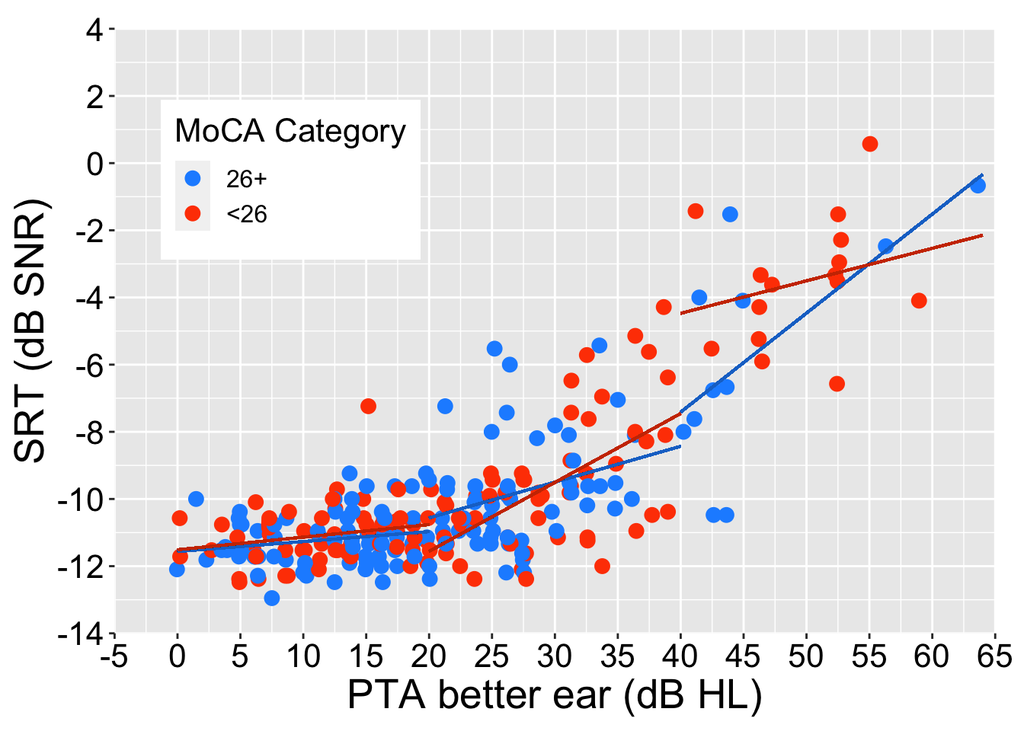

*Mild hearing loss only*: Effect of PTA only

```r
summary(lm(SRT ~ PTA.better * MoCA.cat.num, subset(data2, PTA.group == "Mild")))
```

```
##
## Call:
## lm(formula = SRT ~ PTA.better * MoCA.cat.num, data = subset(data2,
##     PTA.group == "Mild"))
##
## Residuals:
##     Min      1Q  Median      3Q     Max
## -3.2630 -0.9563 -0.1591  0.7592  4.5069
##
## Coefficients:
##                          Estimate Std. Error t value Pr(>|t|)
## (Intercept)             -12.69580    1.39945  -9.072 1.16e-14 ***
## PTA.better                0.10660    0.05087   2.095   0.0387 *
## MoCA.cat.num             -2.96837    1.86491  -1.592   0.1146
## PTA.better:MoCA.cat.num   0.09865    0.06537   1.509   0.1344
## ---
## Signif. codes:  0 '***' 0.001 '**' 0.01 '*' 0.05 '.' 0.1 ' ' 1
##
## Residual standard error: 1.591 on 99 degrees of freedom
## Multiple R-squared:  0.2313, Adjusted R-squared:  0.208
## F-statistic:  9.93 on 3 and 99 DF,  p-value: 8.78e-06
```

#### Figure 3: Three PTA groups, by Faisal’s cognitive categories (normal vs. MCI)

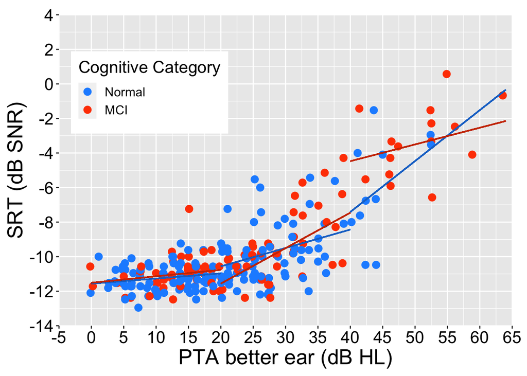

*Mild hearing loss only*: Effect of PTA, no effect of Cognitive Category, weak interaction

```r
summary(lm(SRT ~ PTA.better * Cog.cat.num, subset(data2, PTA.group == "Mild")))
```

```
##
## Call:
## lm(formula = SRT ~ PTA.better * Cog.cat.num, data = subset(data2,
##     PTA.group == "Mild"))
##
## Residuals:
##     Min      1Q  Median      3Q     Max
## -3.0927 -1.0292 -0.1278  0.7902  4.6635
##
## Coefficients:
##                         Estimate Std. Error t value Pr(>|t|)
## (Intercept)            -12.97115    1.15775 -11.204  < 2e-16 ***
## PTA.better               0.11135    0.04103   2.714  0.00784 **
## Cog.cat.num             -2.99034    1.83418  -1.630  0.10621
## PTA.better:Cog.cat.num   0.11248    0.06313   1.782  0.07786 .
## ---
## Signif. codes:  0 '***' 0.001 '**' 0.01 '*' 0.05 '.' 0.1 ' ' 1
##
## Residual standard error: 1.583 on 99 degrees of freedom
## Multiple R-squared:  0.2389, Adjusted R-squared:  0.2159
## F-statistic: 10.36 on 3 and 99 DF,  p-value: 5.441e-06
```

#### Figure 4. SRT-PTA residuals calculated from overall regression line

The SRT-PTA residuals are calculated from the regression line across all PTA Groups.  
There is no significant relationship between MoCA and residuals for the Normal and Mild groups. There is a significant relationship for the Moderate group; r = -0.39, p = 0.046.

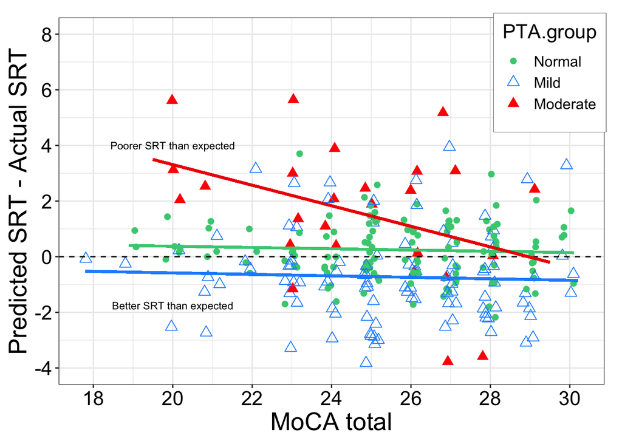

```r
with(subset(resdata, PTA.group == "Normal"), cor.test(residuals, MoCA.total))
```

```
##
##  Pearson's product-moment correlation
##
## data:  residuals and MoCA.total
## t = -0.64655, df = 130, p-value = 0.5191
## alternative hypothesis: true correlation is not equal to 0
## 95 percent confidence interval:
##  -0.2253079  0.1153735
## sample estimates:
##         cor
## -0.05661505
```

```r
with(subset(resdata, PTA.group == "Mild"), cor.test(residuals, MoCA.total))
```

```
##
##  Pearson's product-moment correlation
##
## data:  residuals and MoCA.total
## t = -0.44048, df = 101, p-value = 0.6605
## alternative hypothesis: true correlation is not equal to 0
## 95 percent confidence interval:
##  -0.2353175  0.1510175
## sample estimates:
##         cor
## -0.04378687
```

```r
with(subset(resdata, PTA.group == "Moderate"), cor.test(residuals, MoCA.total))
```

```
##
##  Pearson's product-moment correlation
##
## data:  residuals and MoCA.total
## t = -2.1064, df = 24, p-value = 0.04582
## alternative hypothesis: true correlation is not equal to 0
## 95 percent confidence interval:
##  -0.678530645 -0.009024198
## sample estimates:
##        cor
## -0.3949954
```

#### Figure 5. Residuals calculated from group-specific regression line

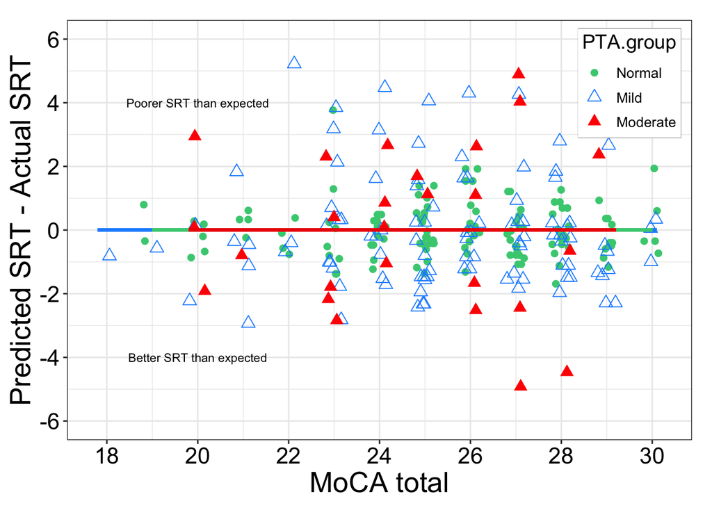